# Simulation of Market Sales Variations

Kin

July 12, 2016

# 1 Abstract

Sales of different brands change every years but it is not certain how much of these changes are caused by random factors instead of observable factors such as different market strategy or changes in market structure. Using the history of brands chosen last year, the probability of choosing a brand when buying tea can be evaluated as the proportion of the brand among all tea product purchased. Through simulating the purchase of all households with the probability generated, the overall sales of different brands can be reconstructed and the distributions of possible sales of different brands can be obtained. This method can be further generalised into transforming any distribution of lower aggregation of sales into probabilities density to simulate potential category results. The flow chart below explains the idea.

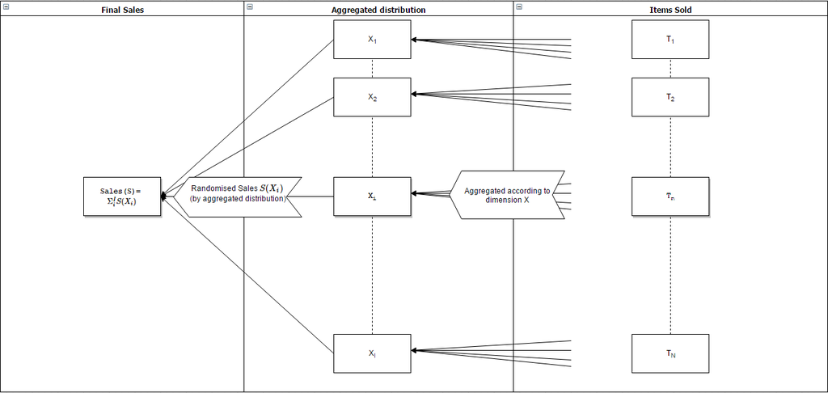

One alternative way is to estimate the probability of the sales of shops by theirs sales distributions and then simulate the result with shopwise brand dsitributions.

To generalise the case explicitly mathematically, consider a number of brands $B_1,B_2,....,B_I$ and respective recorded sales $S_{B_1},...,S_{B_I}$. The sales can be considered as an aggregation of lower aggregation level $X_1,.....X_J$ such that,

$$S_{B_i}=\Sigma_j^J S_{B_i}(X_j)$$

where $S_{B_i}(X_j)$ denotes the sales of brand $B_i$ within aggregation segment $X_j$.

For each $X_j$, the Sales $S_{X_j}$ within $X_j$ would have a distribution $S_{X_j}(B_i)$ such that

$$S_{X_j}=\Sigma_i^I S_{X_j}(B_i)$$

where $S_{X_j}(B_i)$ denote the sales of brand $B_i$ within aggregated segment $X_j$.

$X$ could be households, shop, a district or demographical segments.

The variance of the distribution simulated then serves as an estimation of variance under the assumption that the distribution observed was sufficient to describe the underlying probability.

In this report, models with $X$ as households or shops will be applied on the data to investigate the volatility of the market sales. The variance of market shares will be investigated by both explicit calculation by CLT[2] or Monte Carlo simulation with different assumptions and levels of aggregations. The goal is to ultimately suggest how volatile the market is and how much of the changes in market shares could be explained by the pure randomness without changing or altering possible correlations and expectations of different variables.

# 2 Data

This report used the tea panel data from Kantar in year 2014 constrained to the “Mainstream” sub-sector category.

The data is composed of 5 different databases:

1.) Demographical data of households - 10310 Houses

2.) Attributes of tea products - 4530 products

3.) Attributes of Stores/shops - 826 stores

5.) Trips to stores/shops - 835530 observations

The further details of data treatment[1] is written on the appendix.

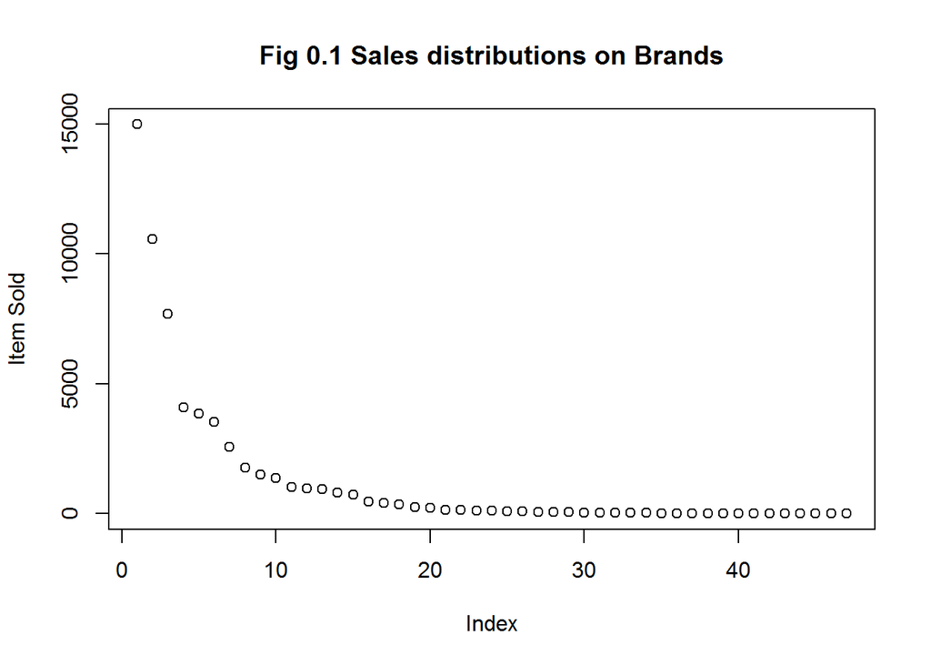

```r
tea <- read.csv("C:/Users/cheukkin.Warwick/Desktop/CheukData/Data/dat_tea_new.csv")
rst_tripspend <- read.csv("C:/Users/cheukkin.Warwick/Desktop/CheukData/Data/rst_tripspend.csv")
Attr_tea <- read.csv("C:/Users/cheukkin.Warwick/Desktop/CheukData/Data/Attr_tea.csv")
stores<-read.csv("C:/Users/cheukkin.Warwick/Desktop/CheukData/Data/stores.csv")
demogs <- read.csv("C:/Users/cheukkin.Warwick/Desktop/CheukData/Data/demogs.csv")
tea_train2014<-read.csv("C:/Users/cheukkin.Warwick/Desktop/CheukData/Data/tea_train2014.csv")
tea_train2015<-read.csv("C:/Users/cheukkin.Warwick/Desktop/CheukData/Data/tea_train2015.csv")
trips_train2014<-read.csv("C:/Users/cheukkin.Warwick/Desktop/CheukData/Data/trips_train2014.csv")
trips_train2015<-read.csv("C:/Users/cheukkin.Warwick/Desktop/CheukData/Data/trips_train2015.csv")
##BRAND Range
#RANGE_COUNT
######
#2014#
######

Brands_COUNT<-tea_train2014 %>% left_join(Attr_tea,by="PRODUCT")%>% group_by(Range.Trading.Company,Branded.Private.Label)%>%summarise(range_counts=length(Range.Trading.Company)) %>% ungroup() %>% arrange(desc(range_counts))
plot(Brands_COUNT$range_counts,main="Fig 0.1 Sales distributions on Brands",ylab="Item Sold",xlab="Index")
```

```r
Brands_COUNT$RANGE_type=as.character(Brands_COUNT$Range.Trading.Company)
Brands_COUNT$RANGE_type[Brands_COUNT$range_counts<4000 & Brands_COUNT$Branded.Private.Label=="Private Label"]="others_PL"
Brands_COUNT$RANGE_type[Brands_COUNT$range_counts<1000 & Brands_COUNT$Branded.Private.Label=="Branded"]="others_BRD"

BRAND_Range<-Brands_COUNT %>% group_by(RANGE_type) %>% summarise(RANGE_type_count=sum(range_counts)) %>% right_join(Brands_COUNT,by="RANGE_type") %>% left_join(Attr_tea,by="Range.Trading.Company")


######
#2015#
######

Brands_COUNT2<-tea_train2015 %>% left_join(Attr_tea,by="PRODUCT")%>% group_by(Range.Trading.Company,Branded.Private.Label)%>%summarise(range_counts=length(Range.Trading.Company)) %>% ungroup() %>% arrange(desc(range_counts))
Brands_COUNT2$RANGE_type=as.character(Brands_COUNT2$Range.Trading.Company)
Brands_COUNT2$RANGE_type[Brands_COUNT2$range_counts<4000 & Brands_COUNT2$Branded.Private.Label=="Private Label"]="others_PL"
Brands_COUNT2$RANGE_type[Brands_COUNT2$range_counts<1000 & Brands_COUNT2$Branded.Private.Label=="Branded"]="others_BRD"

BRAND_Range2<-Brands_COUNT2 %>% group_by(RANGE_type) %>% summarise(RANGE_type_count=sum(range_counts)) %>% right_join(Brands_COUNT2,by="RANGE_type") %>% left_join(Attr_tea,by="Range.Trading.Company")

Original<-tea_train2014 %>% left_join(BRAND_Range,by="PRODUCT") %>% group_by(RANGE_type) %>% summarise(Sales2014=length(RANGE_type))
Original$RANGE_type[5]<-"Tetley.Standard.Bags"
Original$RANGE_type[7]<-"Yorkshire.Tea"
knitr::kable(Original[with(Original, order(-Sales2014)), ])
```

| RANGE_type | Sales2014 |
| --- | --- |
| others_PL | 17727 |
| P.G.Tips | 14985 |
| Tetley.Standard.Bags | 10569 |
| Yorkshire.Tea | 7689 |
| Typhoo | 4081 |
| others_BRD | 2362 |
| R.Twining | 1769 |

# 3 Results and conclusion

In order to investigate the underlying randomness of market shares, the tea data of 2014 was applied to investigate the distribution of the potential market shares under the different assumptions. The data was tested against four different models to investigate the potential randomness in terms of variance of market sales.

In the following sections, the results of different models will be presented in the tables below. The terms used in the tables are explained below. For the distributions of sales of different brands, please see appendix[4].

MEAN: Expected sales of of the brand.

SD: Standard deviation of sales.

MEAN_percentage_total: The percentage sales of the total tea sales.

SD_percentage_mean: The SD as percentage of MEAN sales.

Confident_lvl95: The percentage change of sales contributed by pure randomness within 95% confident level.

```r
SHARE_SIM1 <- read.csv("C:/Users/cheukkin.Warwick/Desktop/CheukData/Data/sim_shopper_distribution.csv")
sim_shop_share <- read.csv("C:/Users/cheukkin.Warwick/Desktop/CheukData/Data/sim_shop_distribution.csv")
TOTAL_DISTRIBUTION <- read.csv("C:/Users/cheukkin.Warwick/Desktop/CheukData/Data/TOTAL_DISTRIBUTION.csv")
sim_new_share <- read.csv("C:/Users/cheukkin.Warwick/Desktop/CheukData/Data/CF_result500.csv")

MEAN=c(mean(SHARE_SIM1$P.G.Tips),mean(SHARE_SIM1$R.Twining),mean(SHARE_SIM1$Tetley.Standard.Bags),mean(SHARE_SIM1$Typhoo),mean(SHARE_SIM1$Yorkshire.Tea),mean(SHARE_SIM1$others_PL),mean(SHARE_SIM1$others_BRD))

MEAN_percentage_total<-MEAN*100/sum(MEAN)

SD=c(sd(SHARE_SIM1$P.G.Tips),sd(SHARE_SIM1$R.Twining),sd(SHARE_SIM1$Tetley.Standard.Bags),sd(SHARE_SIM1$Typhoo),sd(SHARE_SIM1$Yorkshire.Tea),sd(SHARE_SIM1$others_PL),sd(SHARE_SIM1$others_BRD))

SD_percentage_mean<-SD*100/MEAN

Confident_lvl95<-SD_percentage_mean*qt(.975,10309)

STAT_TABLE<-data.frame(MEAN,SD,MEAN_percentage_total,SD_percentage_mean,Confident_lvl95)

rownames(STAT_TABLE)<-c("P.G.Tips","R.Twining","Tetley.Standard.Bags","Typhoo","Yorkshire.Tea","others_PL","others_BRD")
STAT_TABLE<-STAT_TABLE[with(STAT_TABLE, order(-MEAN)), ]



MEAN=c(mean(sim_shop_share$P.G.Tips),mean(sim_shop_share$R.Twining),mean(sim_shop_share$Tetley.Standard.Bags),mean(sim_shop_share$Typhoo),mean(sim_shop_share$Yorkshire.Tea),mean(sim_shop_share$others_PL),mean(sim_shop_share$others_BRD))

SD=c(sd(sim_shop_share$P.G.Tips),sd(sim_shop_share$R.Twining),sd(sim_shop_share$Tetley.Standard.Bags),sd(sim_shop_share$Typhoo),sd(sim_shop_share$Yorkshire.Tea),sd(sim_shop_share$others_PL),sd(sim_shop_share$others_BRD))

MEAN_percentage_total=MEAN*100/sum(MEAN)
SD_percentage_mean=SD*100/MEAN

Confident_lvl95<-SD_percentage_mean*qt(.975,10309)

STAT_TABLE2<-data.frame(MEAN,SD,MEAN_percentage_total,SD_percentage_mean,Confident_lvl95)

rownames(STAT_TABLE2)<-c("P.G.Tips","R.Twining","Tetley.Standard.Bags","Typhoo","Yorkshire.Tea","others_PL","others_BRD")
STAT_TABLE2<-STAT_TABLE2[with(STAT_TABLE2, order(-MEAN)), ]


MEAN=c(mean(TOTAL_DISTRIBUTION$P.G.Tips),mean(TOTAL_DISTRIBUTION$R.Twining),mean(TOTAL_DISTRIBUTION$Tetley.Standard.Bags),mean(TOTAL_DISTRIBUTION$Typhoo),mean(TOTAL_DISTRIBUTION$Yorkshire.Tea),mean(TOTAL_DISTRIBUTION$others_PL),mean(TOTAL_DISTRIBUTION$others_BRD))

SD=c(sd(TOTAL_DISTRIBUTION$P.G.Tips),sd(TOTAL_DISTRIBUTION$R.Twining),sd(TOTAL_DISTRIBUTION$Tetley.Standard.Bags),sd(TOTAL_DISTRIBUTION$Typhoo),sd(TOTAL_DISTRIBUTION$Yorkshire.Tea),sd(TOTAL_DISTRIBUTION$others_PL),sd(TOTAL_DISTRIBUTION$others_BRD))

MEAN_percentage_total=MEAN*100/sum(MEAN)
SD_percentage_mean=SD*100/MEAN

Confident_lvl95<-SD_percentage_mean*qt(.975,10309)

STAT_TABLE3<-data.frame(MEAN,SD,MEAN_percentage_total,SD_percentage_mean,Confident_lvl95)
rownames(STAT_TABLE3)<-c("P.G.Tips","R.Twining","Tetley.Standard.Bags","Typhoo","Yorkshire.Tea","others_PL","others_BRD")
STAT_TABLE3<-STAT_TABLE3[with(STAT_TABLE3, order(-MEAN)), ]


MEAN=c(mean(sim_new_share$P.G.Tips),mean(sim_new_share$R.Twining),mean(sim_new_share$Tetley.Standard.Bags),mean(sim_new_share$Typhoo),mean(sim_new_share$Yorkshire.Tea),mean(sim_new_share$others_PL),mean(sim_new_share$others_BRD))

SD=c(sd(sim_new_share$P.G.Tips),sd(sim_new_share$R.Twining),sd(sim_new_share$Tetley.Standard.Bags),sd(sim_new_share$Yorkshire.Tea),sd(sim_new_share$Typhoo),sd(sim_new_share$others_PL),sd(sim_new_share$others_BRD))

MEAN_percentage_total=MEAN*100/sum(MEAN)
SD_percentage_mean=SD*100/MEAN

Confident_lvl95<-SD_percentage_mean*qt(.975,10309)

STAT_TABLE4<-data.frame(MEAN,SD,MEAN_percentage_total,SD_percentage_mean,Confident_lvl95)
rownames(STAT_TABLE4)<-c("P.G.Tips","R.Twining","Tetley.Standard.Bags","Typhoo","Yorkshire.Tea","others_PL","others_BRD")

STAT_TABLE4<-STAT_TABLE4[with(STAT_TABLE4, order(-MEAN)), ]
```

## 3.1 Basic Models

The first two models are the simple static household and shop models. They involving only the lowest level of combination changes. The correlations and expectations of variables within the data are well preserved.

### 3.1.1 household Model

The household model evaluates the probability of brand choices of each purchase by the distribution of brand chosen among the tea product purchase. Using this probability distribution, the possible brand choices were simulated to estimate the market sales variances.

```r
knitr::kable(STAT_TABLE)
```

|  | MEAN | SD | MEAN_percentage_total | SD_percentage_mean | Confident_lvl95 |
| --- | --- | --- | --- | --- | --- |
| others_PL | 17727.392 | 51.54377 | 29.954027 | 0.2907578 | 0.5699416 |
| P.G.Tips | 14984.566 | 55.37431 | 25.319465 | 0.3695423 | 0.7243747 |
| Tetley.Standard.Bags | 10570.284 | 49.05315 | 17.860640 | 0.4640666 | 0.9096605 |
| Yorkshire.Tea | 7685.494 | 43.40163 | 12.986202 | 0.5647214 | 1.1069636 |
| Typhoo | 4082.478 | 40.47139 | 6.898175 | 0.9913437 | 1.9432262 |
| others_BRD | 2361.742 | 26.72512 | 3.990642 | 1.1315850 | 2.2181262 |
| R.Twining | 1770.044 | 23.28042 | 2.990849 | 1.3152453 | 2.5781362 |

### 3.1.2 Shop Model

Instead of doing the customized simulation, the simulation can also be done shop wise by taking the distribution of sales of each shops and simulate the purchases using shop wise distribution. Each purchase will then be generated from the shop distribution.

```r
knitr::kable(STAT_TABLE2)
```

|  | MEAN | SD | MEAN_percentage_total | SD_percentage_mean | Confident_lvl95 |
| --- | --- | --- | --- | --- | --- |
| others_PL | 17722.574 | 102.19454 | 29.945886 | 0.5766349 | 1.130316 |
| P.G.Tips | 14983.562 | 105.34401 | 25.317769 | 0.7030639 | 1.378142 |
| Tetley.Standard.Bags | 10566.846 | 91.74087 | 17.854831 | 0.8681954 | 1.701831 |
| Yorkshire.Tea | 7690.442 | 80.31810 | 12.994563 | 1.0443886 | 2.047204 |
| Typhoo | 4084.158 | 61.18277 | 6.901014 | 1.4980511 | 2.936471 |
| others_BRD | 2362.200 | 46.79786 | 3.991416 | 1.9811135 | 3.883367 |
| R.Twining | 1772.218 | 41.80145 | 2.994522 | 2.3587081 | 4.623526 |

## 3.2 Further models

In this part, other possible source of randomness such as the number of shopping visits and the amount of tea product consumed were further introduced into the two basic models, aim to further estimate a larger possible range of randomness.

### 3.2.1 Further shop model

This model is a further extension of the shop model in which the data was dissected into weekly data. The weekly number of visits received by each shops were randomized according to their distribution. The chance of each visit to have tea in the basket was calculated according to the proportion of baskets with tea. The probability of brand choice was evaluated according to the weekly sales distribution of the respective shop. The result is shown below.

```r
knitr::kable(STAT_TABLE3)
```

|  | MEAN | SD | MEAN_percentage_total | SD_percentage_mean | Confident_lvl95 |
| --- | --- | --- | --- | --- | --- |
| others_PL | 17709.560 | 129.75586 | 30.056815 | 0.7326882 | 1.436211 |
| P.G.Tips | 14980.022 | 124.62893 | 25.424220 | 0.8319676 | 1.630818 |
| Tetley.Standard.Bags | 10539.914 | 102.31563 | 17.888431 | 0.9707444 | 1.902848 |
| Yorkshire.Tea | 7692.472 | 91.52240 | 13.055728 | 1.1897658 | 2.332172 |
| Typhoo | 3870.160 | 70.10449 | 6.568468 | 1.8114107 | 3.550717 |
| others_BRD | 2360.430 | 48.36299 | 4.006142 | 2.0489060 | 4.016254 |
| R.Twining | 1767.724 | 41.38775 | 3.000196 | 2.3413015 | 4.589405 |

### 3.2.2 Further household model

This model further randomized the possible purchase pattern of households according to their demographical background, shopping experiences and history of purchase. The model first found out shops which provide similar shopping experiences and then searched for households with closest shopping experiences. The probability of brand choice of a household was then randomized with the purchase history of closest households according to their brand choice similarity.

```r
knitr::kable(STAT_TABLE4)
```

|  | MEAN | SD | MEAN_percentage_total | SD_percentage_mean | Confident_lvl95 |
| --- | --- | --- | --- | --- | --- |
| others_PL | 17601.806 | 54.31616 | 29.968798 | 0.3085829 | 0.6048823 |
| P.G.Tips | 14891.072 | 59.50429 | 25.353508 | 0.3995971 | 0.7832878 |
| Tetley.Standard.Bags | 10473.674 | 50.06184 | 17.832455 | 0.4779779 | 0.9369294 |
| Yorkshire.Tea | 7642.926 | 42.95522 | 13.012830 | 0.5620258 | 1.1016796 |
| Typhoo | 4047.786 | 42.96254 | 6.891752 | 1.0613837 | 2.0805182 |
| others_BRD | 2328.666 | 27.08856 | 3.964782 | 1.1632651 | 2.2802254 |
| R.Twining | 1747.844 | 25.12996 | 2.975875 | 1.4377688 | 2.8183060 |

## 3.3 conclusions

For the household models, the standard deviation of the market sales is under-estimated due to lacking information of seldom buyers as well as unknown structure of tea using habits of users. On the other hand, although shop models do not suffer from this problem, it could over-estimate the sales deviations as its aggregation level is much higher than the household models.

To strike a balance between the two models, the mean of two results was taken.

```r
STAT_TABLE_Result<-(STAT_TABLE3+STAT_TABLE4)/2
knitr::kable(STAT_TABLE_Result)
```

|  | MEAN | SD | MEAN_percentage_total | SD_percentage_mean | Confident_lvl95 |
| --- | --- | --- | --- | --- | --- |
| others_PL | 17655.683 | 92.03601 | 30.012806 | 0.5206355 | 1.020547 |
| P.G.Tips | 14935.547 | 92.06661 | 25.388864 | 0.6157823 | 1.207053 |
| Tetley.Standard.Bags | 10506.794 | 76.18873 | 17.860443 | 0.7243611 | 1.419889 |
| Yorkshire.Tea | 7667.699 | 67.23881 | 13.034279 | 0.8758958 | 1.716926 |
| Typhoo | 3958.973 | 56.53352 | 6.730110 | 1.4363972 | 2.815617 |
| others_BRD | 2344.548 | 37.72578 | 3.985462 | 1.6060856 | 3.148239 |
| R.Twining | 1757.784 | 33.25885 | 2.988036 | 1.8895352 | 3.703856 |

From the result, it can be concluded that changes in yearly market sales are not due to pure randomness at a 95% confidence level if the changes of sales exceed,

$$\text{Last year sales} \times \text{Confident_lvl95}$$
.

Despite the differences between the models, all of them showed a similar scale of deviations according the their market shares. The standard deviations of sales appear to be inversely proportional to the percentage of total sales in all the models[4]. From the plot, the volatility of other brands could be estimated according to their market shares.

Fig 1.1 below shows the result obtained by taking the mean of the household model and shop model.

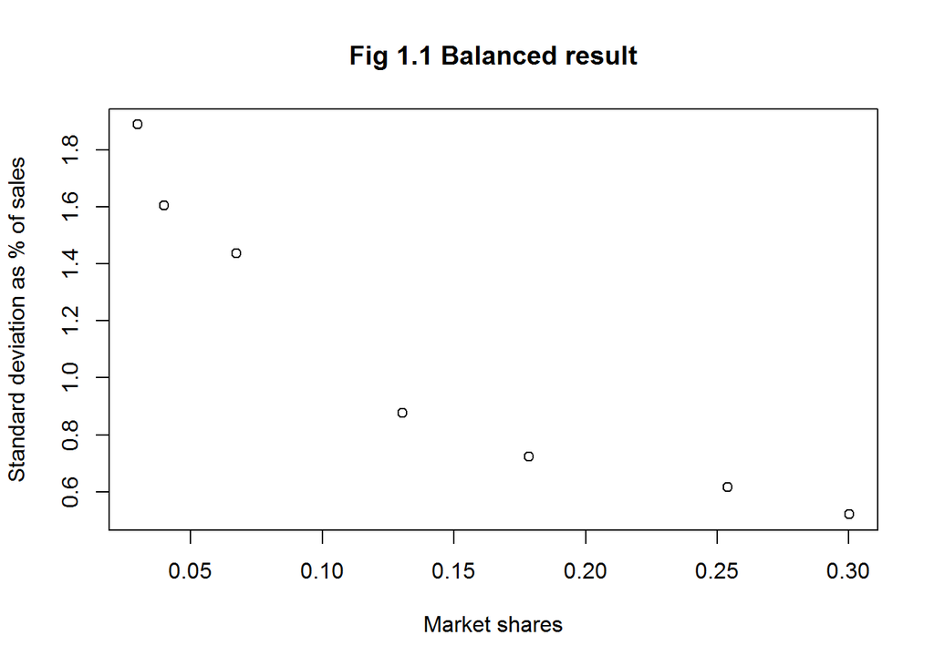

```r
plot(STAT_TABLE_Result$MEAN/sum(STAT_TABLE_Result$MEAN),STAT_TABLE_Result$SD_percentage_mean,main="Fig 1.1 Balanced result",ylab="Standard deviation as % of sales",xlab="Market shares")
```

# 4 Models details and limitations

## 4.1 Basic Models

These are the most conservative models aim to model the underlying randomness of the market shares without altering any underlying variables nor describing any relationship between variables.

### 4.1.1 household Model

The household model evaluates the probability of brand choices of each purchase by the distribution of brand products bought by the household. Using this probability distribution, the possible brand choices were simulated to estimate the market sales variances.

Let the amount of product $j$ the shopper/household $i$ would purchase be $X_{ij}$. Given the known demand of a shopper/household $i$ be $n$, the distribution of $X_{ij}$ is then modeled as a multinomial distribution of power $n$ and probabilities $p_{ij}$ where $p_{ij}$ is the percentage of the brand $j$ shopper/household $i$ bought in year 2014.

To simulate the market share in 2014, the probability distributions[3] for each brand of each shoppers in the data are generated and used for the simulation of 500 different possible market shares results.

***The variance and mean of market sales can also be estimated directly by the CLT[2].

```r
#############################
###Shopper-wise Simulation###
#############################
#The probability distributions of shoppers buying different brand of tea were calculated below, stored in the data frame "Shopperwise_table".

Shopperwise<-tea_train2014 %>% left_join(stores,by=c("SHOPCODE"="ShopCode")) %>% left_join(BRAND_Range,by="PRODUCT")
Shopperwise_table<-as.data.frame.matrix(table(Shopperwise$HOUSE,Shopperwise$RANGE_type))
Shopperwise_table$HOUSE=rownames(Shopperwise_table)
Shopperwise_table$Total=apply(Shopperwise_table[,1:7],1,FUN = sum)
```

```r
#Below is the function used for the simulation using data frame input with the format as "shopperwise_table".

#Basic simulation

##Functions

bin_sim<-function(table,start_col,end_col,total_col){

  res<-table[,total_col]
  prob_res<-table[,total_col]
  result<-table
  for(i in (start_col:(end_col-1))){
    result[,i]<-suppressWarnings(rbinom(length(table[,i]),res,table[,i]/prob_res))
    res<-res-result[,i]
    prob_res<-prob_res-table[,i]
  }
  result[,end_col]<-res
  result[is.na(result)]<-0
  return(result)
}

summarise_bin_sim<-function(bin_sim_result,start_col,end_col){
  return(apply(bin_sim_result[,start_col:end_col],2,FUN=sum))
  }
```

```r
#The result is then calculated and stored in a csv file for further analysis.
sim_shopper_distribution<-summarise_bin_sim(bin_sim(Shopperwise_table,1,7,9),1,7)

for(k in 1:499){
  sim_shopper_distribution<-rbind(sim_shopper_distribution,summarise_bin_sim(bin_sim(Shopperwise_table,1,7,9),1,7))
}

write.csv(sim_shopper_distribution,paste("C:/Users/cheukkin.Warwick/Desktop/CheukData/Data/sim_shopper_distribution.csv",sep=""))
```

#### 4.1.1.1 Model limitations

The reliability of this model mainly based on the belief that the shopping history of households was sufficient to reveal consistent shopping habits and choice of brands of households given that households visit shops and experience the same shopping experience as before.

As there is only one year data, the accuracy of the assumption could be very limited especially for those seldom buyers of tea. In one extreme case where the household only made one purchase of tea product in the year, the model prediction is almost absolutely wrong. For instance, current model assigns 100% probability of buying brand X if the household bought X once and only once this year. Hence, the variances of the amount of brand X these customers may buy could be much higher than what are assigned by the model which means that the actual variance of market shares may be much higher than what is obtained from the model. To understand how much is this potential error contributed by such assumption, it is useful to see the following distribution below.

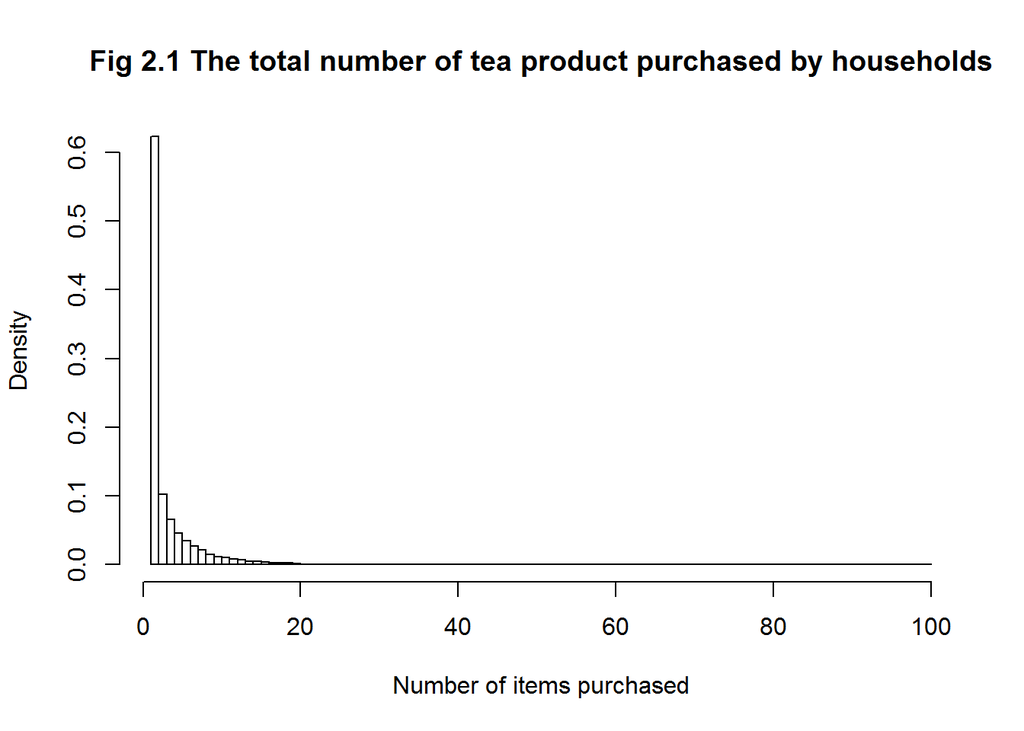

```r
customers_portfolio<- tea_train2014 %>% left_join(Attr_tea,by="PRODUCT") %>% group_by(Range.Trading.Company,HOUSE) %>% summarise(freq=length(HOUSE))
customers_portfolio<- customers_portfolio %>% group_by(HOUSE) %>% mutate(Brand_percentage=freq/sum(freq)) %>% mutate(loyalty=max(Brand_percentage),variety=n_distinct(Range.Trading.Company))
customers_portfolio<- customers_portfolio %>% group_by(HOUSE) %>% mutate(Brand_percentage=freq/sum(freq))
customers_portfolio<- customers_portfolio %>% left_join(select(Brands_COUNT,1,4),by="Range.Trading.Company")

hist(customers_portfolio$freq,breaks=c(1:20,100),main="Fig 2.1 The total number of tea product purchased by households",xlab="Number of items purchased")
```

Fig 2.1 above shows that over 60% of the tea users only buy once a year and over 70% of them only buy once or twice a year. Together, they occupied 70% of total households and individual behavior of this group of customers are very hard to be predicted as their choice and preference cannot be fully reveal by a few purchase observations.

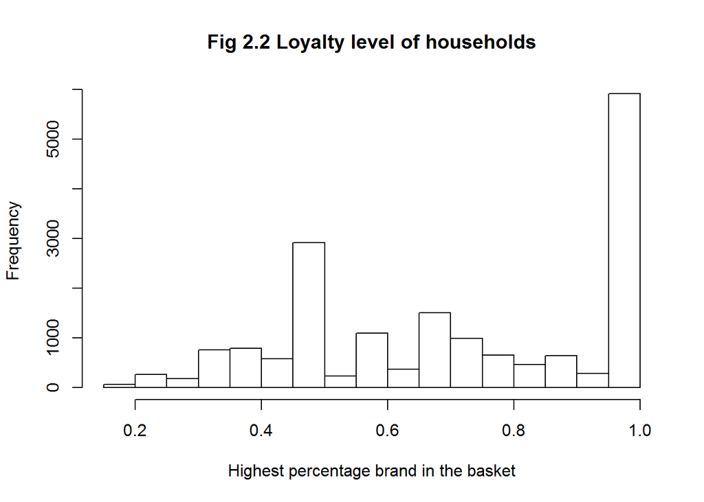

```r
hist(customers_portfolio$loyalty,nclass=(0.1*(0:10)),main="Fig 2.2 Loyalty level of households",xlab="Highest percentage brand in the basket")
```

Fig 2.2 above shows the loyalty level of customers which is the percentage of purchase of the favorite brand of the households. There are huge spikes on 1 and 0.5 as a result of large proportion of seldom users in the data.

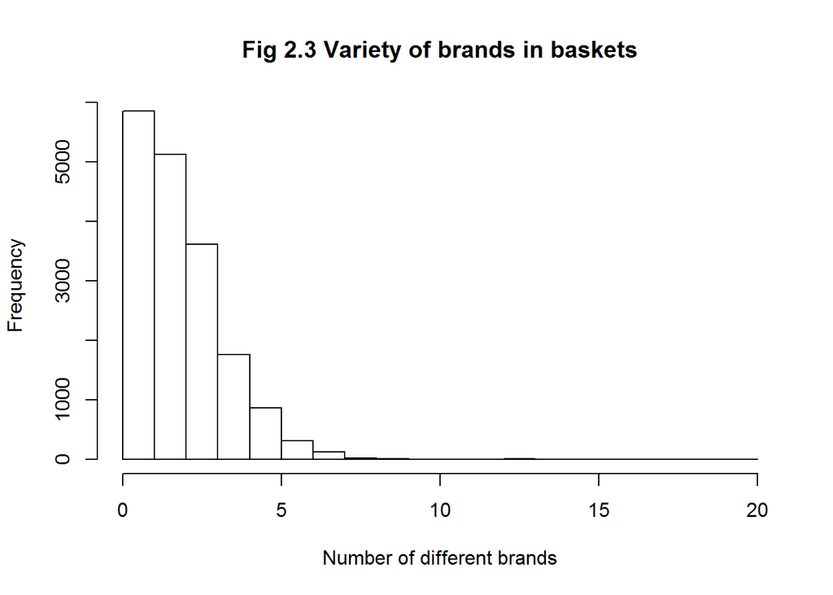

```r
hist(customers_portfolio$variety,breaks=0:20,main="Fig 2.3 Variety of brands in baskets",xlab="Number of different brands")
```

Fig 2.3 shows the brand variety of brands in households’ baskets.

Besides the problem of under-estimated variability of brand choice probability, the variances of the total sales were also ignored in this model. So this model can only reveal the partly the estimated market variation contributed by those more frequent buyers.

Furthermore, the model also assumed that households have consistent tea consumption habits. By comparing with baskets in 2014 with 2015, the consistency of tea consumption can be estimated.

```r
Shopperwise2015<-tea_train2015 %>% left_join(stores,by=c("SHOPCODE"="ShopCode")) %>% left_join(BRAND_Range,by="PRODUCT")
Shopperwise2015_table<-as.data.frame.matrix(table(Shopperwise2015$HOUSE,Shopperwise2015$RANGE_type))
Shopperwise2015_table$HOUSE=rownames(Shopperwise2015_table)
Shopperwise2015_table$Total=apply(Shopperwise2015_table[,1:7],1,FUN = sum)

combine_table<-Shopperwise_table %>% inner_join(Shopperwise2015_table,by="HOUSE")
combine_table$Total_diff<-abs(combine_table$Total.x - combine_table$Total.y)
combine_table$Total_delta<-abs(combine_table$Total.x - combine_table$Total.y)/combine_table$Total.x

knitr::kable(data.frame(Mean_purchase_difference=mean(combine_table$Total_diff),Mean_percentage_differece=mean(combine_table$Total_delta)*100))
```

| Mean_purchase_difference | Mean_percentage_differece |
| --- | --- |
| 2.550442 | 59.711 |

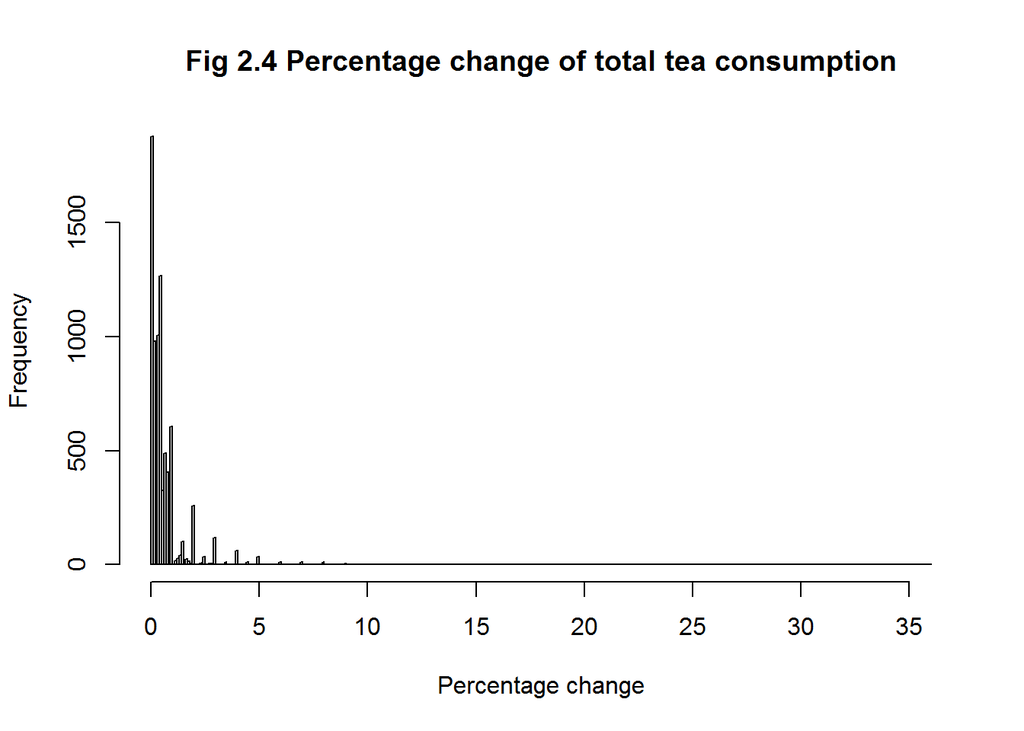

```r
hist(combine_table$Total_delta,breaks=(0:360)*0.1,main="Fig 2.4 Percentage change of total tea consumption",xlab="Percentage change")
```

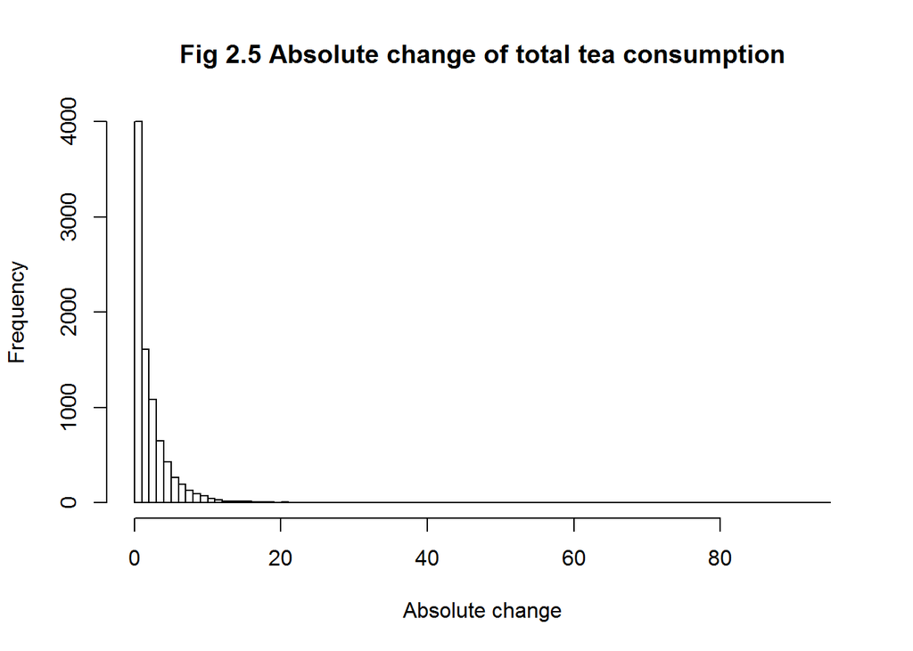

```r
hist(combine_table$Total_diff,breaks=0:95,main="Fig 2.5 Absolute change of total tea consumption",xlab="Absolute change")
```

Fig 2.4 and Fig 2.5 explain further how volatile were the tea consumption patterns. Such dramatic change may be due to incomplete competitive set or the volatile nature of tea consumption and they suggest that the model may have underestimated the underlying randomness. However, even if the whole range of tea products were included, the change in total tea product purchase still differ significantly as what is shown in Fig 2.6 and Fig 2.7.

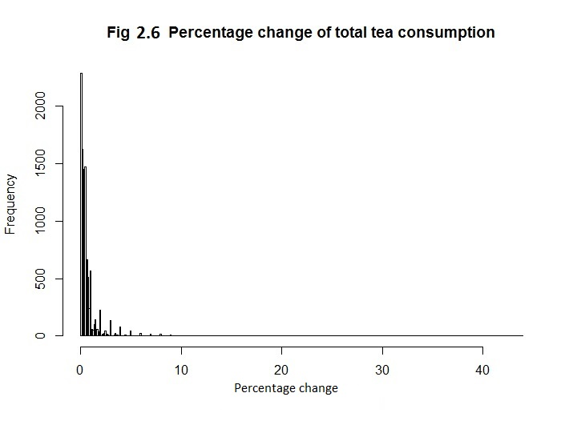

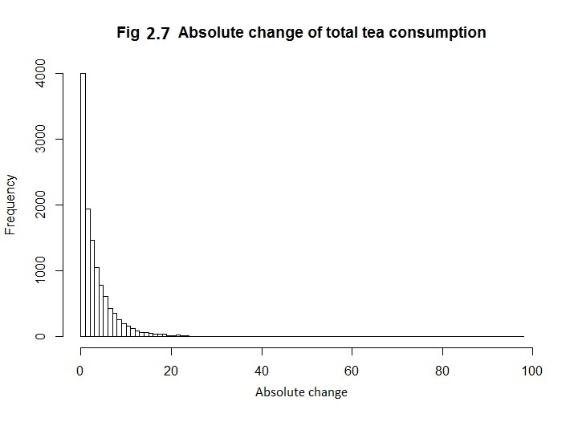

As what have been tested above, the assumption that customers have consistent tea consumption behavior may not be valid. Even if the assumption does hold if the year was replayed, the variance of market shares of this model is still greatly underestimated as variations contributed by seldom buyers and other random factors were not modeled.

### 4.1.2 Shop Model

It is very similar to the first model but it take $X_i$ as shops instead of households. It gets around of the problem that a large amount of households are seldom buyers of tea. The main assumption of this model is that the attributes of shops are sufficient and and number of data points available is enough to fully describe the distributions. Although there are also a small tail of seldom sellers of tea, the percentage of these shops is much less than percentage the seldom buyers in the previous model.

```r
#########################
###Shopwise Simulation###
#########################

Shopwise<-tea_train2014 %>% left_join(stores,by=c("SHOPCODE"="ShopCode")) %>% left_join(BRAND_Range,by="PRODUCT")
Shopwise_table<-as.data.frame.matrix(table(Shopwise$SHOPCODE,Shopwise$RANGE_type))
Shopwise_table$SHOPCODE=rownames(Shopwise_table)
Shopwise_table$Total=apply(Shopwise_table[,1:7],1,FUN = sum)

summarise_bin_sim<-function(bin_sim_result,start_col,end_col){
  return(apply(bin_sim_result[,start_col:end_col],2,FUN=sum))
  }


sim_shop_distribution<-summarise_bin_sim(bin_sim(Shopwise_table,1,7,9),1,7)

for(k in 1:499){
  sim_shop_distribution<-rbind(sim_shop_distribution,summarise_bin_sim(bin_sim(Shopwise_table,1,7,9),1,7))
}

write.csv(sim_shop_distribution,paste("C:/Users/cheukkin.Warwick/Desktop/CheukData/Data/sim_shop_distribution.csv",sep=""))
```

#### 4.1.2.1 Model limitations

The model does not involve customized details and therefore some underlying details of market shares such as brand cooccurences matrix are not simulated. Moreover, as the model is simulated at a much higher aggregated level, the underlying combinations would be more than possible combinations and therefore the variance of market shares could be over-estimated[5]. Furthermore, some of the variations in the market is not included in the model. For example, the market share of each shops are assumed to be constant.

```r
Shop2014_sales<-tea_train2014 %>% group_by(SHOPCODE) %>% summarise(Sales_2014=length(SHOPCODE))
shop2015_sales<-tea_train2015 %>% group_by(SHOPCODE) %>% summarise(Sales_2015=length(SHOPCODE))
Shop_sales<-Shop2014_sales %>% left_join(shop2015_sales,by="SHOPCODE")
Shop_sales$percentage_change<-abs(Shop_sales$Sales_2014-Shop_sales$Sales_2015)*100/Shop_sales$Sales_2014

knitr::kable(Shop_sales[order(Shop_sales$Sales_2014,decreasing=TRUE),][1:10,])
```

| SHOPCODE | Sales_2014 | Sales_2015 | percentage_change |
| --- | --- | --- | --- |
| 170 | 9416 | 8861 | 5.894223 |
| 790 | 8366 | 7433 | 11.152283 |
| 780 | 7517 | 6770 | 9.937475 |
| 710 | 5574 | 5778 | 3.659849 |
| 770 | 5475 | 4716 | 13.863014 |
| 786 | 4737 | 4117 | 13.088453 |
| 782 | 2669 | 2965 | 11.090296 |
| 490 | 2365 | 2122 | 10.274841 |
| 705 | 2096 | 2218 | 5.820611 |
| 901 | 1399 | 1349 | 3.573981 |

The table above shows the variations in tea product sales from 2014 to 2015 of the top 10 biggest stores. The variations in tea product sales is relatively narrow when compared with the variations of the sales of household model.

## 4.2 Further Models

### 4.2.1 Further randomised shop model

The randomness simulated can be very subjective and model dependence. As more random variables were introduced into the model, the more wide spread is the final sales distribution. This model is a further relaxation of the simple shop model, introducing more possible underlying combination randomness of aggregation.

#### 4.2.1.1 Randomised weeks of visits

The number of visits received by each shop were first randomized according to the weekly distribution across the year.

Given a shop $Y$ received $M_Y$ visits in 2014, $M_Y$ was assumed to be constant. The distribution of these $M_Y$ visits were then randomized with multinomial distribution simulation across different weeks. The number of visits $M_Y(W)$ received by the shop at week $W$ is modeled as a multinomial distribution of power $M_Y$ and probabilities $P_{M_Y}(W)$ of different weeks.

#### 4.2.1.2 Randomised tea sales

The weekly ratio of visits and tea product sales was calculated as and taken as the probability $Q_{Y}(W)$ that a tea product would be bought in a visit. The amount of tea sales $S_{Y}(W)$ was modeled by a multinomial distribution of power $M_{Y}(W)$ with probabilities $Q_{Y}(W)$.

#### 4.2.1.3 Brand Shares

The brand shares was now calculated same way as the previous basic shop model. The probability $P_{Y_B}(W)$ of selling a brand $B$ in a shop $Y$ was calculated according to the proportion of sales of the brand $B$ to total tea product sales $S_{Y}(W)$ in the shop of week $W$. The simulated sales $S_{Y_B}(W)$ of the brand $B$ was simulated by multinomial distribution of power $S_{Y_B}(W)$ with probabilities $P_{Y_B}(W)$. The yearly market shares were calculated simply by summing up the weekly sales.

```r
#Randomised Visiting days
Visits_2014<-as.data.frame.matrix(table(trips_train2014$SHOPCODE,trips_train2014$WEEK))
Visits_2014$SHOPCODE<-as.character(rownames(Visits_2014))
Visits_2014$total<-apply(Visits_2014[,1:52],1,FUN=sum)
New_Visits<-bin_sim(Visits_2014,1,52,54)
New_Visits$SHOPCODE<-as.character(New_Visits$SHOPCODE)

#Calculate the proportion of tea purchase
Tea_trip<-as.data.frame.matrix(table(tea_train2014$SHOPCODE,tea_train2014$WEEK))
Tea_trip$SHOPCODE<-rownames(Tea_trip)
Tea_trip$total<-apply(Tea_trip[,1:52],1,FUN=sum)

Tea_prob<-Tea_trip %>% left_join(Visits_2014,by="SHOPCODE")
Tea_prob[,1:52]<-Tea_prob[,1:52]/Tea_prob[,55:106]
Tea_prob$total.x<-Tea_prob$total.x/Tea_prob$total.y
is.nan.data.frame <- function(x)
do.call(cbind, lapply(x, is.nan))

Tea_prob<-Tea_prob[,1:54]
Tea_prob[is.nan(Tea_prob)]<-0
colnames(Tea_prob)<-c(paste("P",1:52,sep=""),"SHOPCODE","PT")


#Sales distribution across the week
Sales_distribution<-tea_train2014 %>% left_join(BRAND_Range,by="PRODUCT")

Wk_Sales<-function(RELWEEK,Sales_distribution,New_Visits){
  SALES<-Sales_distribution[Sales_distribution$RELWEEK==RELWEEK,]
  Sales_table<-as.data.frame.matrix(table(SALES$SHOPCODE,SALES$RANGE_type))
  Sales_table$SHOPCODE=rownames(Sales_table)
  Sales_table$Total=apply(Sales_table[,1:7],1,FUN = sum)
  Sales_table[,1:7]<-Sales_table[,1:7]/Sales_table$Total

  suppressWarnings(Visits<-data.frame(SHOPCODE=as.character(Sales_table[,"SHOPCODE"]))  %>% left_join(New_Visits,by="SHOPCODE"))
  Prob<-Tea_prob[,c(RELWEEK,53)] %>% right_join(Visits,by="SHOPCODE")
  Wk_Visit<-rbinom(Prob[,RELWEEK+2],Prob[,RELWEEK+2],Prob[,1])

  Sales_table[,1:7]<-Sales_table[,1:7]*Wk_Visit
  Sales_table$Total<-Wk_Visit
  weekly_sales<-bin_sim(Sales_table,1,7,9)

  RESULT<-weekly_sales[,c(1:7,9)] %>% summarise_each(funs(sum))
  return(RESULT)
}

#Simulate all weeks
  TOTAL_SHARES<-Wk_Sales(1,Sales_distribution,bin_sim(Visits_2014,1,52,54))
  for(wk in 2:52){
    TOTAL_SHARES<-TOTAL_SHARES+Wk_Sales(wk,Sales_distribution,bin_sim(Visits_2014,1,52,54))
  }

  TOTAL_DISTRIBUTION<-TOTAL_SHARES

for(k in 1:499){
    TOTAL_SHARES<-Wk_Sales(1,Sales_distribution,bin_sim(Visits_2014,1,52,54))
  for(wk in 2:52){
    TOTAL_SHARES<-TOTAL_SHARES+Wk_Sales(wk,Sales_distribution,bin_sim(Visits_2014,1,52,54))
  }
  TOTAL_DISTRIBUTION<-rbind(TOTAL_DISTRIBUTION,TOTAL_SHARES)
}

write.csv(TOTAL_DISTRIBUTION,paste("C:/Users/cheukkin.Warwick/Desktop/CheukData/Data/TOTAL_DISTRIBUTION.csv",sep=""))
```

#### 4.2.1.4 Model limitations

As the data was dissected with much more dimensions, there might not be enough data to describe the underlying randomness and it could still be under-estimated. For example, some dissection of shops and weeks contain very few data points and so the underlying variations or distributions of those dissections could be greatly erroneous.

### 4.2.2 household model - Randomized household model

Collaborative filtering is a technique used for recommendation systems. Different kind of collaborative filtering technique was widely applied on different kind of online marketing recommendation such as online vendors and stores. The idea of collaborative filtering is to adopt the preference of households with similar shopping history as a prediction of potential preference.

Applying the same idea, this model attempt to make use of the aggregation to randomise the underlying probability of brand choices.

First, shops were clustered according to their sales distribution of tea products, assuming that shop with similar sales distribution with tea products provide similar shopping experience in terms of buying tea. After that, households in the same demographical segment with similar shopping pattern were found according to the shops they visited. Their purchase history were then further compared, households with similar baskets were considered as possible purchase history variations with the corresponding probability scaled according to the differences between baskets.

#### 4.2.2.1 Shops Similarity

To find out customers with similar shopping experience, shops that provide similar shopping experience must be located.

Consider the a purchase decisions of households are made according to the offers they obeserved, it is necessary to find out which group of customers received similar information about different products.

Assumed that the sales of products of shops reflects household experience provided by the shop including product availabilities and special offers, shops were clustered according to the distribution of sales of tea products. Those within the same cluster were considered to be providing similar shopping experience.

Hierachical clustering, using Euclidean distance and Ward link is adopted for the clustering.

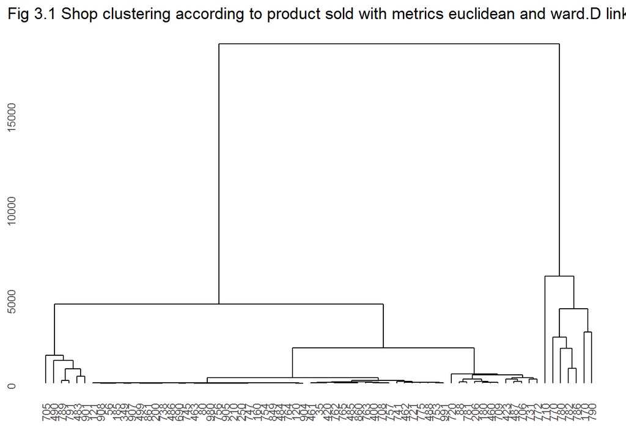

```r
#############################################
#Shop clustering - by product availability#
#############################################

shelf_list=tea_train2014 %>% left_join(Attr_tea,by="PRODUCT")
shelf_table=table(shelf_list$SHOPCODE,as.character(shelf_list$Range.Trading.Company))
shelf_mat=as.data.frame.matrix(shelf_table)

#trail 5
dist_M="euclidean"
link="ward.D"

d=dist(shelf_mat,method=dist_M,p=2)
clust5=hclust(d, method = link, members = NULL)
ggd<-ggdendrogram(clust5) + labs(title=paste("Fig 3.1 Shop clustering according to product sold with metrics",dist_M,"and",link,"link",sep=" "))
ggd
```

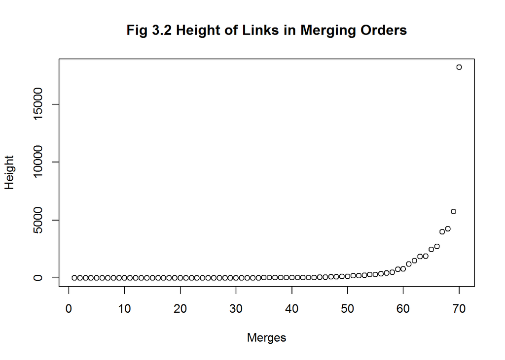

```r
plot(clust5$height,main="Fig 3.2 Height of Links in Merging Orders",ylab = "Height", xlab = "Merges")
```

```r
#check the clusters
cluster_check<-tea_train2014 %>% left_join(stores,by=c("SHOPCODE"="ShopCode")) %>% left_join(Attr_tea,by="PRODUCT")%>% group_by(SHOPCODE,Range.Trading.Company) %>% summarise(count=length(Range.Trading.Company)) %>% left_join(stores,by=c("SHOPCODE"="ShopCode"))%>%select(1,2,3,7)
cuts<-cutree(clust5,k=20)

cut5=data.frame(SHOPCODE=as.integer(names(cuts)),shop_cluster5=cuts)
shop_check5<-cluster_check %>% left_join(cut5,by="SHOPCODE")
shop_cluster5_list<-shop_check5 %>% select(1,4,5) %>% distinct()
```

According to Fig 3.2, a cut with 20 clusters was employed. Fig 3.1 shows the structure of the stores clusters.

#### 4.2.2.2 Shopping experience

households were compared according to the set of shops they visited to estimate their shopping experience. Euclidean distance was used to measure the similarity of shop experiences of households. Each household $i$ and $j$ were then compared according to their shop visits using Euclidean distance metric $Eu_{ij}$.

```r
####################
##demog clustering##
####################


##########################################
###demog - cluster by products exposure###
##########################################
dist_M="euclidean"
shop_clust5_list<-shop_check5 %>% select(1,4,5) %>% distinct()
visit_list<-trips_train2014 %>% left_join(demogs,by="HOUSE") %>% left_join(shop_clust5_list, by="SHOPCODE")
visit_table=table(HOUSE=visit_list$HOUSE,shop_cluster5=visit_list$shop_cluster5)
m=as.matrix(dist(visit_table,method=dist_M))
```

#### 4.2.2.3 Purchase history

Each household $i$ and $j$ were also compared according to their history of purchase using Euclidean distance metric $eu_{ij}$.

```r
############################################
###demog - cluster by brand range choices###
############################################


preference<-tea_train2014 %>% left_join(select(BRAND_Range,1,2),by="PRODUCT") %>% group_by(HOUSE,RANGE_type) %>% summarise(freq=length(HOUSE))

preference<-spread(preference, RANGE_type, freq)
preference[is.na(preference)]=0
HOUSE_list=preference$HOUSE
pref_table<-preference[,c(2:8)]
rownames(pref_table)=HOUSE_list
pref_table<-as.table(as.matrix(pref_table))

dist_M="euclidean"
m2<-as.matrix(dist(pref_table,method=dist_M))
```

#### 4.2.2.4 Randomization of purchase history

$K_i$ households in the same demographic segments with the most similar shopping experience as each household $i$ were chosen and indexed by $k$ according the Euclidean measure $Eu_{ik}$.

The importance of their purchase histories as references for household $i$ preferences were weighted by
$$\text{weight}_{ik} = \text{exp}(-\beta eu_{ik})$$
.

where $\beta$ is a parametre to be optimized.

The probability that a household $i$ would have had a purchase history as household $ik$ is calculated as,

$$\frac{\text{weight}_{ik}}{\Sigma_h^{K_i} \text{weight}_{ih}}$$

and further simulated and replace the original purchase history.

```r
######################################################################
###New probability prediction according to distance from neighbours###
######################################################################
preference$HOUSE=as.integer(HOUSE_list)

n_nbr<-function(dist_matrix,HOUSE,n_neightbour){
  return(rownames(dist_matrix)[order(dist_matrix[HOUSE,])[1:n_neightbour]])

}


New_combination<-function(m,m2,HOUSE,n_neigh,beta,years){

  neightbour_list<-intersect(n_nbr(m,HOUSE,n_neigh),colnames(m2))

#  Dem_seg<-demogs$HOUSE[demogs$SIZE==demogs[demogs$HOUSE==HOUSE,]$SIZE & demogs$LIFESTGE==demogs[demogs$HOUSE==HOUSE,]$LIFESTGE & demogs$SCLASS==demogs[demogs$HOUSE==HOUSE,]$SCLASS]

  #neightbour_list<-intersect(neightbour_list,Dem_seg)

  neigh_choices<-data.frame(distance=m2[HOUSE,as.character(neightbour_list)],HOUSE=as.integer(neightbour_list)) %>% left_join(preference,by="HOUSE") %>% mutate(weights=exp(-distance*beta))
  base=sum(neigh_choices$weights)
  neigh_choices$Prob=neigh_choices$weights/base
  new_prob<-data.frame(YEAR=1:years,HOUSE=as.integer(sample(as.character(neigh_choices$HOUSE), size=years, replace=TRUE, prob=neigh_choices$Prob)))
  new_prob<-new_prob %>% left_join(neigh_choices,by="HOUSE")
  new_prob$Total=apply(new_prob[,4:10],1,FUN = sum)
  RESULT<-bin_sim(new_prob,3,10,13)
  return(RESULT)
}


n_neigh=50
beta=2


CF_prob<-function(m,m2,freq_table,n_neigh,beta,years){
  house_list=freq_table$HOUSE
  new_table<-New_combination(m,m2,as.character(house_list[1]),n_neigh,beta,years)
  for(r in 2:nrow(frequency_table)){
    new_table<-rbind(new_table,New_combination(m,m2,as.character(house_list[r]),n_neigh,beta,years))
    print(r/10261)
  }
  return(new_table)
}
result500<-CF_prob(m,m2,freq_table,n_neigh,beta,years)
write.csv(result500,"C:/Users/cheukkin.Warwick/Desktop/CheukData/Data/result500.csv")
```

The result was simulated with $\beta=2$ is presented below.

```r
#result<-rbind(result300,result100)
CF_result500_8<-result500_8%>% group_by(YEAR) %>% summarise_each(funs(sum)) %>% select(1,4:10)
write.csv(CF_result500_8,"C:/Users/cheukkin.Warwick/Desktop/CheukData/Data/CF_result500_8.csv")
```

```r
STAT_TABLE4$BRAND=rownames(STAT_TABLE4)
knitr::kable(STAT_TABLE4 %>% left_join(Original,by=c("BRAND"="RANGE_type")))
```

| MEAN | SD | MEAN_percentage_total | SD_percentage_mean | Confident_lvl95 | BRAND | Sales2014 |
| --- | --- | --- | --- | --- | --- | --- |
| 17601.806 | 54.31616 | 29.968798 | 0.3085829 | 0.6048823 | others_PL | 17727 |
| 14891.072 | 59.50429 | 25.353508 | 0.3995971 | 0.7832878 | P.G.Tips | 14985 |
| 10473.674 | 50.06184 | 17.832455 | 0.4779779 | 0.9369294 | Tetley.Standard.Bags | 10569 |
| 7642.926 | 42.95522 | 13.012830 | 0.5620258 | 1.1016796 | Yorkshire.Tea | 7689 |
| 4047.786 | 42.96254 | 6.891752 | 1.0613837 | 2.0805182 | Typhoo | 4081 |
| 2328.666 | 27.08856 | 3.964782 | 1.1632651 | 2.2802254 | others_BRD | 2362 |
| 1747.844 | 25.12996 | 2.975875 | 1.4377688 | 2.8183060 | R.Twining | 1769 |

The result of this model has still very limited variance in the market shares. As there are very limited number of households in the data when compared to the number of segments provided, the distribution of households may not be fully revealed. For many households, all the clostest households could be all very different from itself, leading to a very small predicted variation in the possible change of purchase pattern.

#### 4.2.2.5 Model limitations

As the model requires many different dimensions with shopping pattern and the choices of brands, the number of data points required for the algorithm is much more than the data set. Therefore the accuracy of the result could be limited.

## 4.3 household model v.s. Shop model

The household model is believed to under-estimated the market share variance. As there are over 60% of tea buyers were one time buyers, the information available may not be possible to make a prediction on the underlying brand choice probability for this group of buyers. Even if consumers were aggregated to make predictions to fill up these gaps, the accuracy or meaning of the model is still uncertain as the estimated loyalty cannot be tested.

The shop model, on the other hand, suffers from no such constraints as households’ information were no longer included in the model. Instead, households of a shop as an aggregation were considered as an entity. Without the under-estimation of the shpper model, the variance in market shares modelled by the shop model is almost double of what is modelled by the household model. However, as the household model has a higher level of aggregation, the underlying combination allowed will be more than the household model. As a result, the increase in variance may not be solely contributed by the underestimated variance from seldom buyers.

# 5 Appendix

## 5.1 Data treatment

The data was separated into 2014 and 2015 data and filtered so that only subsector “Mainstream” products were in the data. 80% of the data was taken out for model building and the 20% left was for testing.

```r
######################
###To prep the data###
######################

###read data
tea <- read.csv("C:/Users/cheukkin.Warwick/Desktop/CheukData/Data/dat_tea_new.csv")
rst_tripspend <- read.csv("C:/Users/cheukkin.Warwick/Desktop/CheukData/Data/rst_tripspend.csv")
Attr_tea <- read.csv("C:/Users/cheukkin.Warwick/Desktop/CheukData/Data/Attr_tea.csv")
stores<-read.csv("C:/Users/cheukkin.Warwick/Desktop/CheukData/Data/stores.csv")
demogs <- read.csv("C:/Users/cheukkin.Warwick/Desktop/CheukData/Data/demogs.csv")

###Get the Mainsteam sub-sector

Mainstream<-unique(Attr_tea$PRODUCT[Attr_tea$Sub.Sector=="Mainstream"])
tea<-tea[tea$PRODUCT %in% Mainstream,]

### get out the 80%

unique_HOUSE<-unique(rst_tripspend$HOUSE)
sample_size<-length(unique_HOUSE)

HOUSE_train<-sample(unique_HOUSE,size=round(sample_size*0.8,0))
HOUSE_test<- unique_HOUSE[!unique_HOUSE %in% HOUSE_train]

tea_train<-tea[tea$HOUSE %in% HOUSE_train,]
tea_test<-tea[tea$HOUSE %in% HOUSE_test,]

trips_train<-rst_tripspend[rst_tripspend$HOUSE %in% HOUSE_train,]
trips_test<-rst_tripspend[rst_tripspend$HOUSE %in% HOUSE_test,]

### separate 2014 and 2015 data

tea_train2014<-tea_train[tea_train$WEEK<=201452,]
tea_train2015<-tea_train[tea_train$WEEK>201452,]

tea_test2014<-tea_test[tea_test$WEEK<=201452,]
tea_test2015<-tea_test[tea_test$WEEK>201452,]

trips_train2014<-trips_train[trips_train$WEEK<=201452,]
trips_train2015<-trips_train[trips_train$WEEK>201452,]

trips_test2014<-trips_test[trips_test$WEEK<=201452,]
trips_test2015<-trips_test[trips_test$WEEK>201452,]
```

## 5.2 Lyapunov’s Central Limit Theorem

Consider the yearly share of sales the each brand $j$ as a sum of independent variables $X_{ij}$ where $i$ is indexed in different models. Given $\mu_{ij}$ and $\sigma_{ij}^2$, according to Lyapunov ’s Central Limit Theorem, the final distribution of the market shares of different brand $j$ can be evaluated explicitly.

The theorem states that:

Suppose $\{ X_1, X_2, ..., X_i, ...\}$ is a sequence of independent random variables, each with finite expected value $\mu_i$ and variance $\sigma_i^2$. Define,

$$s_n^2 = \sum_{i=1}^n \sigma_i^2$$

If $\exists \delta > 0$ such that the ‘Lyapunov’s condition’,

$$\lim_{n\to\infty} \frac{1}{s_{n}^{2+\delta}} \sum_{i=1}^{n} \operatorname{E}\big[\,|X_{i} - \mu_{i}|^{2+\delta}\,\big] = 0$$

is satisfied, then,

$$\frac{1}{s_n} \sum_{i=1}^{n} (X_i - \mu_i) \ \xrightarrow{d}\ \mathcal{N}(0,\;1)$$
.

According to the theorem, the distribution will be a normal distribution with mean $\mu = \Sigma_i \mu_i$ and variance $\sigma^2=\Sigma_i \sigma_i^2$ as $n$ tend to infinity(or sufficiently large).

Given that each purchase of households can be modeled by binomial distribution, each $\sigma_i^2$ could also be calculated explicitly as

$$\sigma_i^2=np(1-p)$$
,

where $n$ is the number of purchase made by the household and $p$ is the probability of the household buying the product.

## 5.3 Brands sales distributions

### 5.3.1 Basic household model

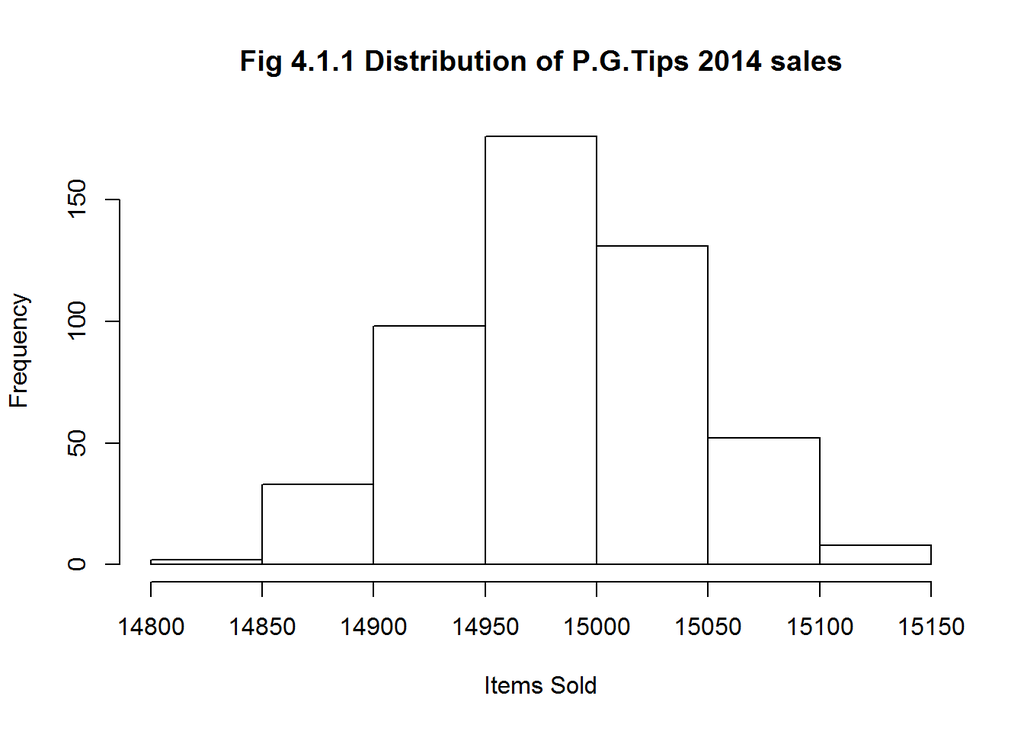

```r
hist(SHARE_SIM1$P.G.Tips,main="Fig 4.1.1 Distribution of P.G.Tips 2014 sales",xlab="Items Sold")
```

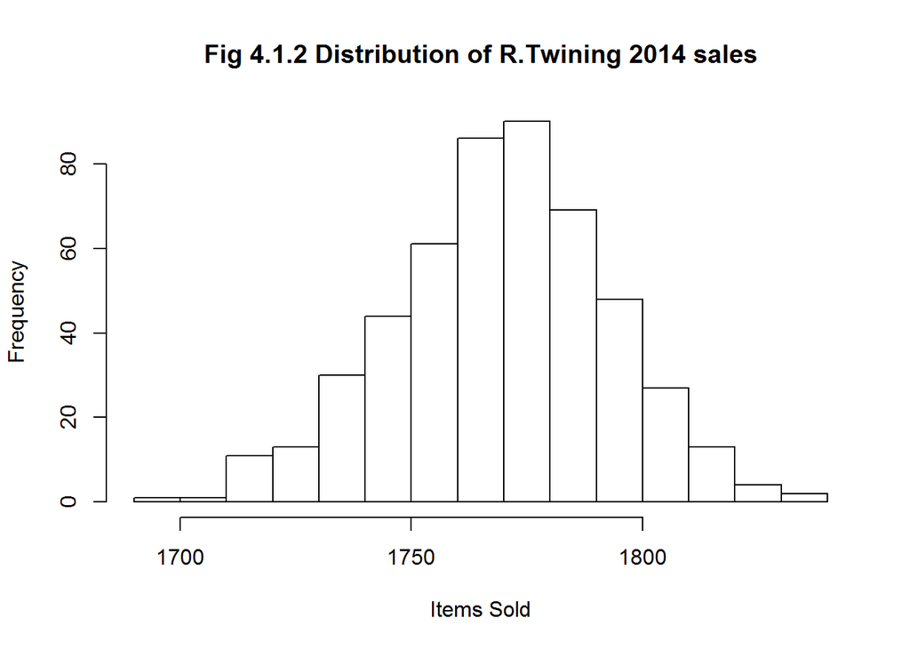

```r
hist(SHARE_SIM1$R.Twining,main="Fig 4.1.2 Distribution of R.Twining 2014 sales",xlab="Items Sold")
```

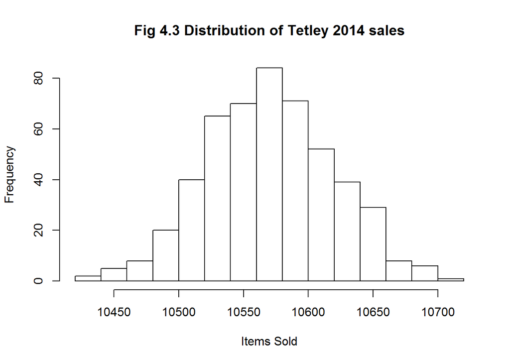

```r
hist(SHARE_SIM1$Tetley.Standard.Bags,main="Fig 4.3 Distribution of Tetley 2014 sales",xlab="Items Sold")
```

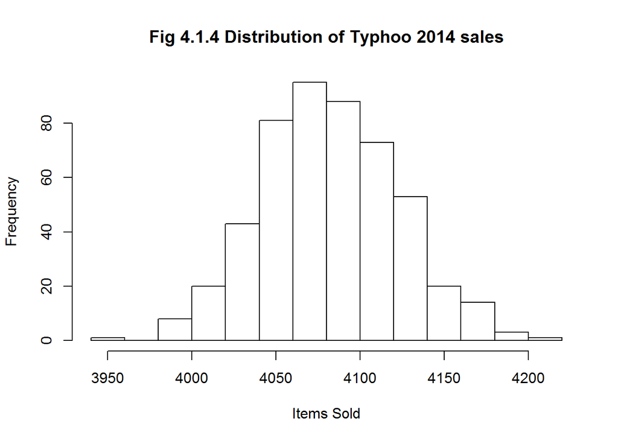

```r
hist(SHARE_SIM1$Typhoo,main="Fig 4.1.4 Distribution of Typhoo 2014 sales",xlab="Items Sold")
```

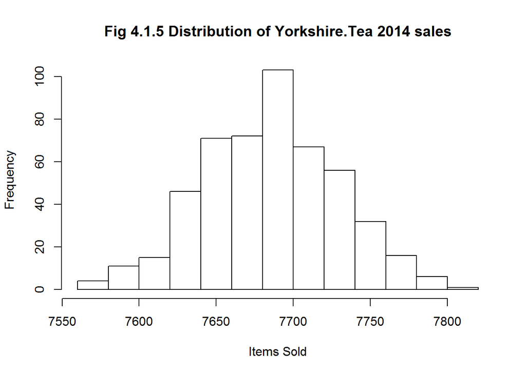

```r
hist(SHARE_SIM1$Yorkshire.Tea,main="Fig 4.1.5 Distribution of Yorkshire.Tea 2014 sales",xlab="Items Sold")
```

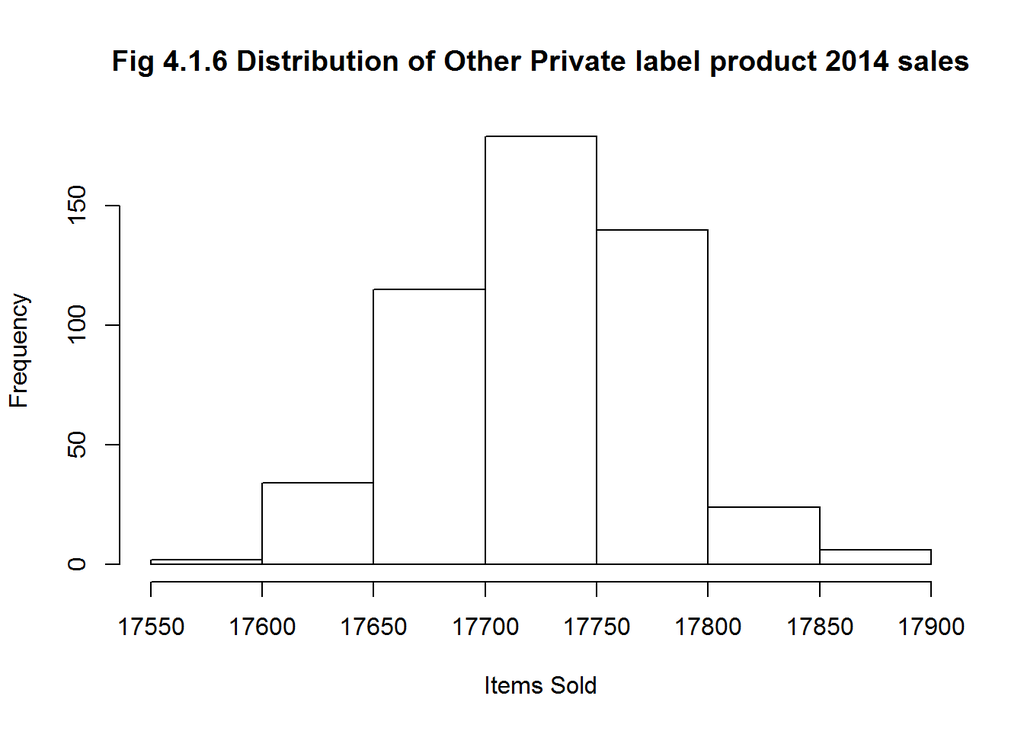

```r
hist(SHARE_SIM1$others_PL,main="Fig 4.1.6 Distribution of Other Private label product 2014 sales",xlab="Items Sold")
```

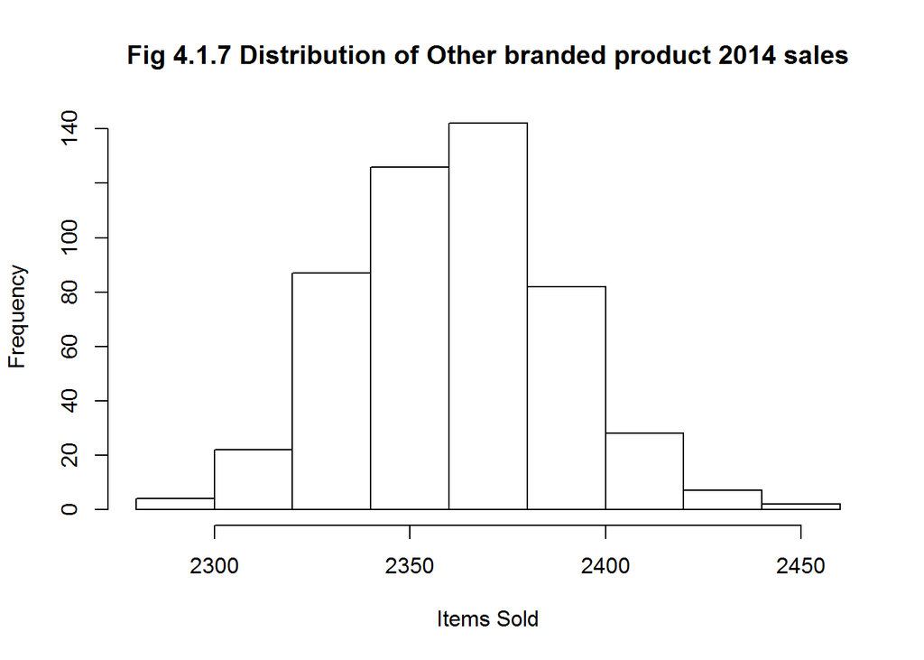

```r
hist(SHARE_SIM1$others_BRD,main="Fig 4.1.7 Distribution of Other branded product 2014 sales",xlab="Items Sold")
```

### 5.3.2 Basic Shop model

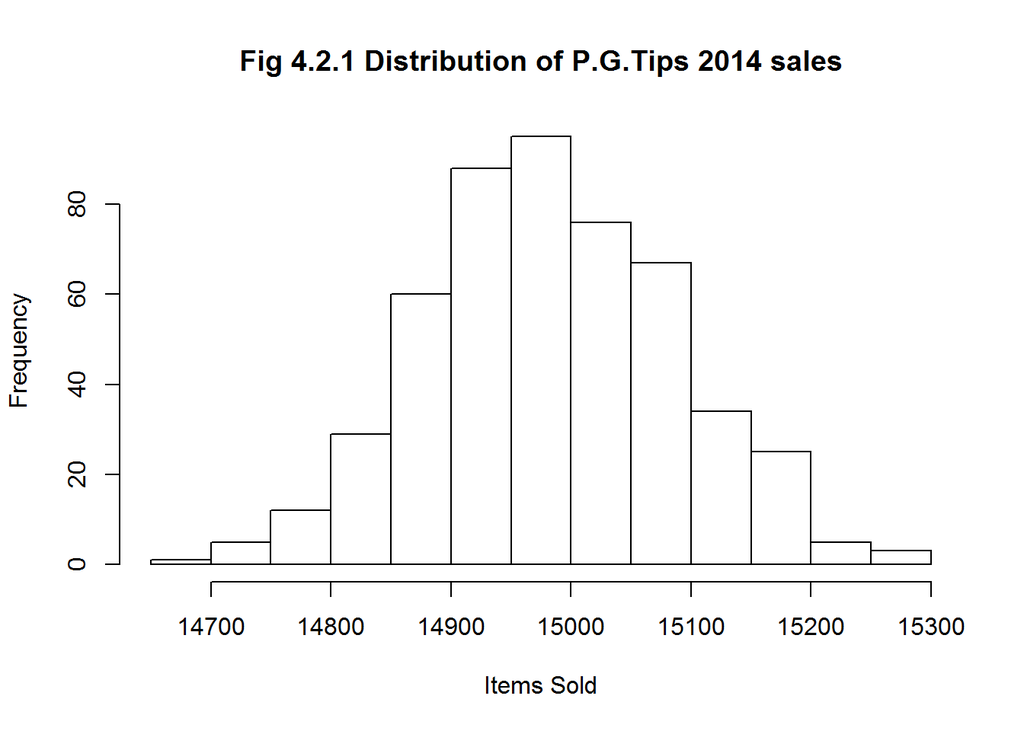

```r
hist(sim_shop_share$P.G.Tips,main="Fig 4.2.1 Distribution of P.G.Tips 2014 sales",xlab="Items Sold")
```

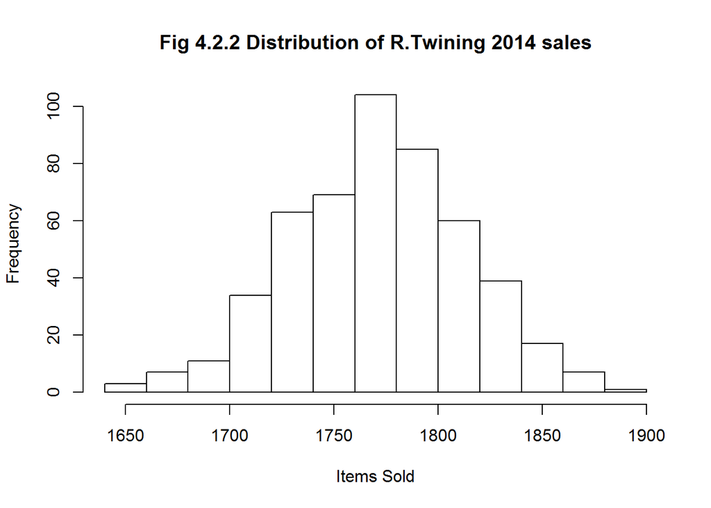

```r
hist(sim_shop_share$R.Twining,main="Fig 4.2.2 Distribution of R.Twining 2014 sales",xlab="Items Sold")
```

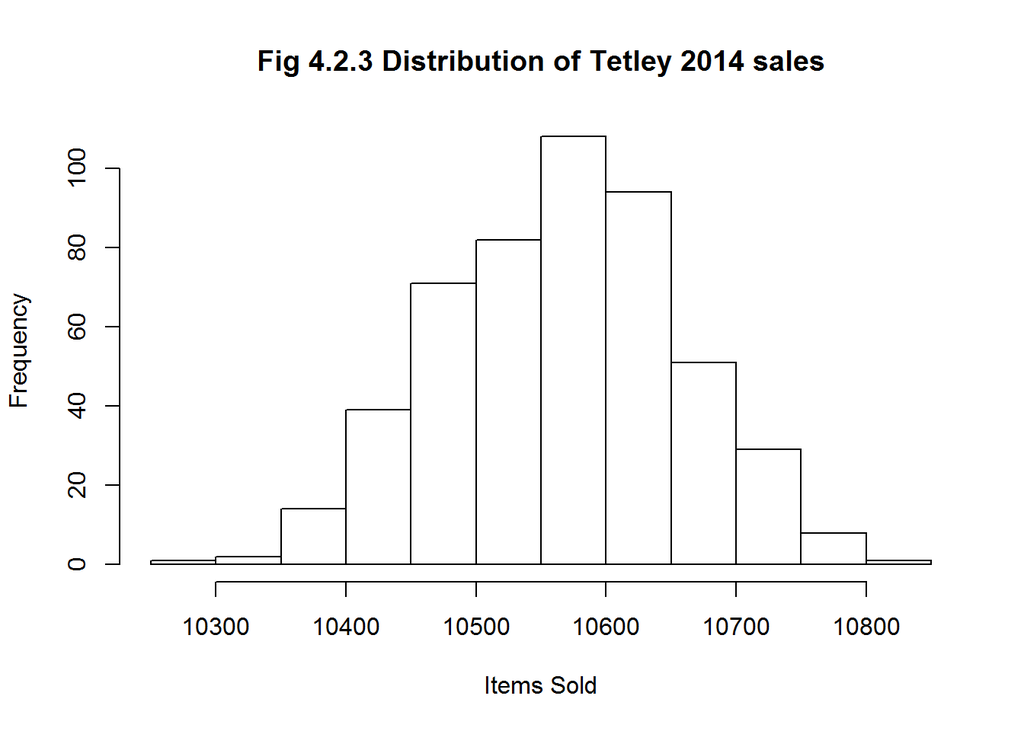

```r
hist(sim_shop_share$Tetley.Standard.Bags,main="Fig 4.2.3 Distribution of Tetley 2014 sales",xlab="Items Sold")
```

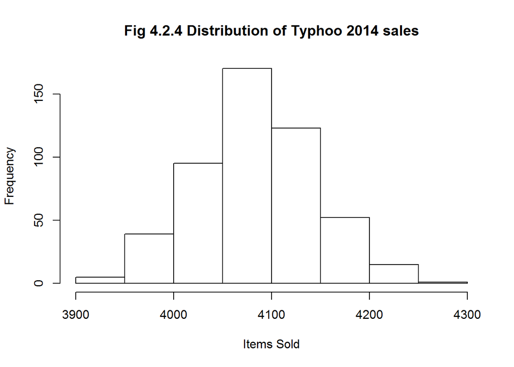

```r
hist(sim_shop_share$Typhoo,main="Fig 4.2.4 Distribution of Typhoo 2014 sales",xlab="Items Sold")
```

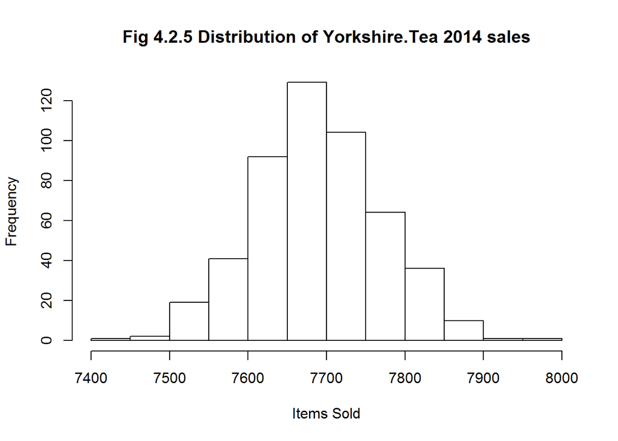

```r
hist(sim_shop_share$Yorkshire.Tea,main="Fig 4.2.5 Distribution of Yorkshire.Tea 2014 sales",xlab="Items Sold")
```

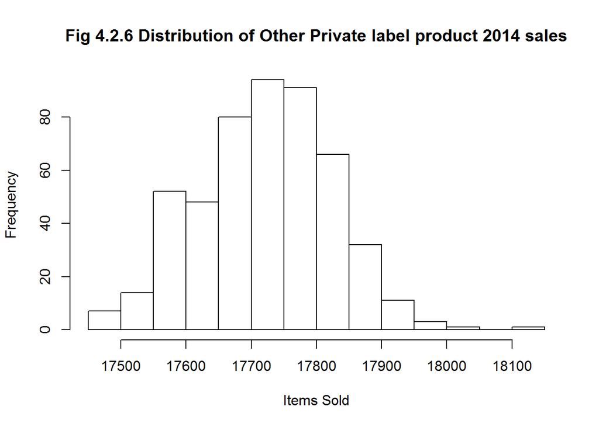

```r
hist(sim_shop_share$others_PL,main="Fig 4.2.6 Distribution of Other Private label product 2014 sales",xlab="Items Sold")
```

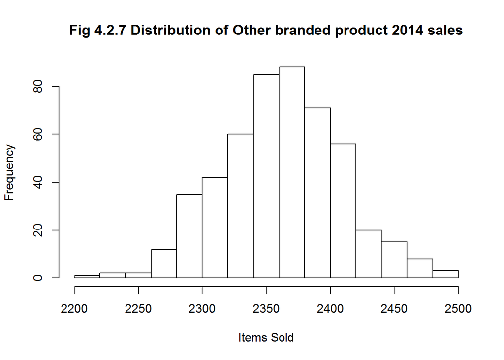

```r
hist(sim_shop_share$others_BRD,main="Fig 4.2.7 Distribution of Other branded product 2014 sales",xlab="Items Sold")
```

### 5.3.3 Further shop model

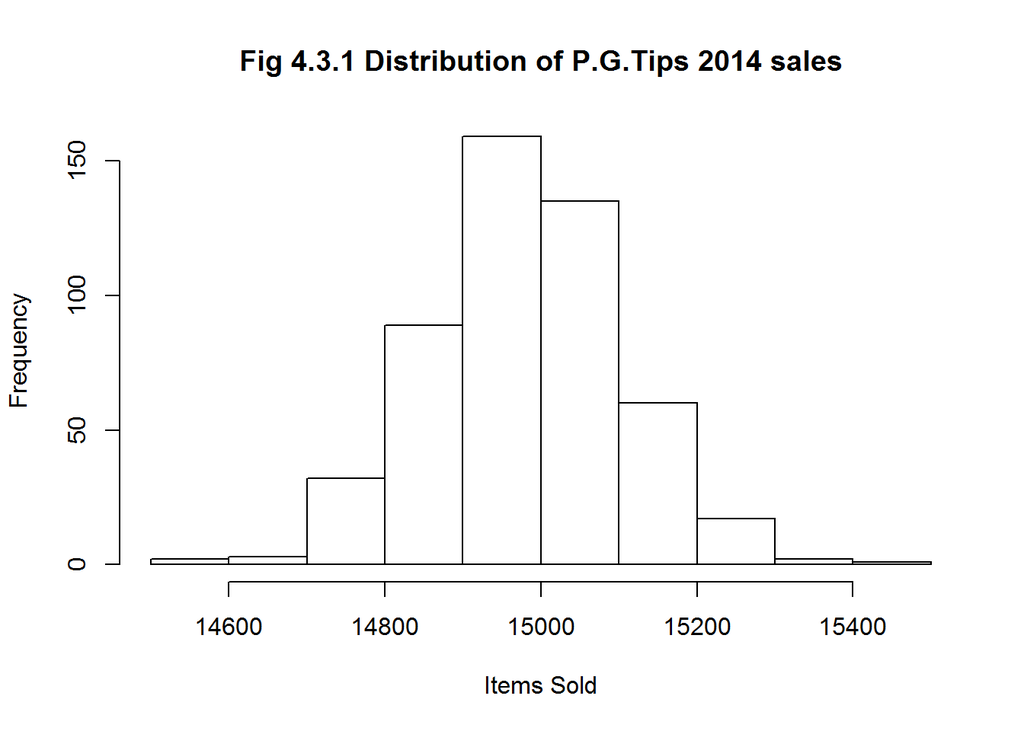

```r
hist(TOTAL_DISTRIBUTION$P.G.Tips,main="Fig 4.3.1 Distribution of P.G.Tips 2014 sales",xlab="Items Sold")
```

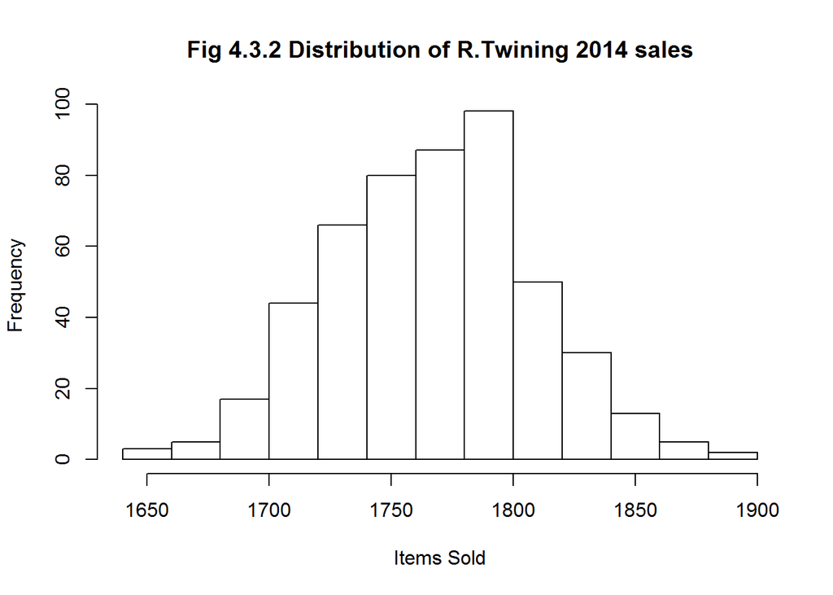

```r
hist(TOTAL_DISTRIBUTION$R.Twining,main="Fig 4.3.2 Distribution of R.Twining 2014 sales",xlab="Items Sold")
```

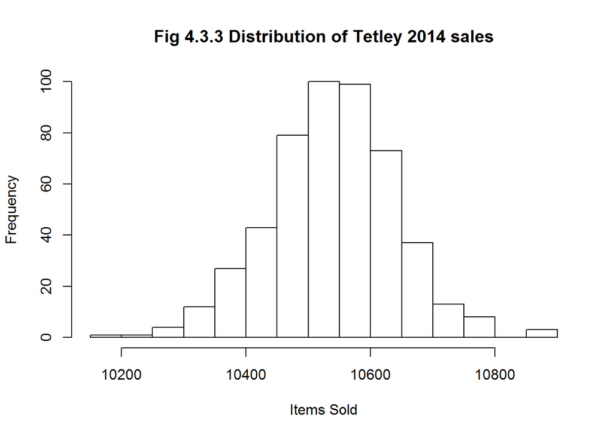

```r
hist(TOTAL_DISTRIBUTION$Tetley.Standard.Bags,main="Fig 4.3.3 Distribution of Tetley 2014 sales",xlab="Items Sold")
```